# Loan Data from Prosper

Prosper Marketplace, Inc. is a San Francisco, California-based company in the peer-to-peer lending industry.In this project, I use their dataset to explore their data which contains 113,937 loans with 81 variables.

Since the dataset is too large and has around 81 variables,I’m subsetting my dataset to consider only those variables which I think will give me a good detailed explanation of my borrowers!

```
## 'data.frame':    113937 obs. of  24 variables:
##  $ ListingNumber            : int  193129 1209647 81716 658116 909464 1074836 750899 768193 1023355 1023355 ...
##  $ CreditGrade              : Factor w/ 9 levels "","A","AA","B",..: 5 1 8 1 1 1 1 1 1 1 ...
##  $ ListingCreationDate      : Factor w/ 113064 levels "2005-11-09 20:44:28.847000000",..: 14184 111894 6429 64760 85967 100310 72556 74019 97834 97834 ...
##  $ Term                     : int  36 36 36 36 36 60 36 36 36 36 ...
##  $ LoanStatus               : Factor w/ 12 levels "Cancelled","Chargedoff",..: 3 4 3 4 4 4 4 4 4 4 ...
##  $ ClosedDate               : Factor w/ 2803 levels "","2005-11-25 00:00:00",..: 1138 1 1263 1 1 1 1 1 1 1 ...
##  $ BorrowerRate             : num  0.158 0.092 0.275 0.0974 0.2085 ...
##  $ CreditScoreRangeLower    : int  640 680 480 800 680 740 680 700 820 820 ...
##  $ ProsperRating..Alpha.    : Factor w/ 8 levels "","A","AA","B",..: 1 2 1 2 6 4 7 5 3 3 ...
##  $ CreditScoreRangeUpper    : int  659 699 499 819 699 759 699 719 839 839 ...
##  $ LenderYield              : num  0.138 0.082 0.24 0.0874 0.1985 ...
##  $ DebtToIncomeRatio        : num  0.17 0.18 0.06 0.15 0.26 0.36 0.27 0.24 0.25 0.25 ...
##  $ ProsperScore             : num  NA 7 NA 9 4 10 2 4 9 11 ...
##  $ ListingCategory..numeric.: int  0 2 0 16 2 1 1 2 7 7 ...
##  $ BorrowerState            : Factor w/ 52 levels "","AK","AL","AR",..: 7 7 12 12 25 34 18 6 16 16 ...
##  $ Occupation               : Factor w/ 68 levels "","Accountant/CPA",..: 37 43 37 52 21 43 50 29 24 24 ...
##  $ IncomeRange              : Factor w/ 8 levels "$0","$1-24,999",..: 4 5 7 4 3 3 4 4 4 4 ...
##  $ TotalProsperLoans        : int  NA NA NA NA 1 NA NA NA NA NA ...
##  $ CurrentDelinquencies     : int  2 0 1 4 0 0 0 0 0 0 ...
##  $ DelinquenciesLast7Years  : int  4 0 0 14 0 0 0 0 0 0 ...
##  $ AmountDelinquent         : num  472 0 NA 10056 0 ...
##  $ LoanOriginalAmount       : int  9425 10000 3001 10000 15000 15000 3000 10000 10000 10000 ...
##  $ LoanOriginationQuarter   : Factor w/ 33 levels "Q1 2006","Q1 2007",..: 18 8 2 32 24 33 16 16 33 33 ...
##  $ LoanOriginationDate      : Factor w/ 1873 levels "2005-11-15 00:00:00",..: 426 1866 260 1535 1757 1821 1649 1666 1813 1813 ...
```

## Cleaning the data variables

After eye-balling the dataset, I saw that there were some variables which required reverse coding, numeric-to-factor conversion and other slight changes.

1. Combining the Creditscore lower and upper range to get a single values for the Credit Score given by the Consumer Credit rating agency. I decided to find the mean of these two columns and assign it as the Credit Score of respective listing.

[output not shown]

2. The listing category variable is of type numeric. COnverting this into a category based on the numeric coding given in the excel :

0 - Not Available, 1 - Debt Consolidation, 2 - Home Improvement, 3 - Business, 4 - Personal Loan, 5 - Student Use, 6 - Auto, 7- Other, 8 - Baby&Adoption, 9 - Boat, 10 - Cosmetic Procedure, 11 - Engagement Ring, 12 - Green Loans, 13 - Household Expenses, 14 - Large Purchases, 15 - Medical/Dental, 16 - Motorcycle, 17 - RV, 18 - Taxes, 19 - Vacation, 20 - Wedding Loans

```
##
## Debt Consolidation   Home Improvement           Business
##              58308               7433               7189
##      Personal Loan        Student Use               Auto
##               2395                756               2572
##    Baby & Adoption               Boat Cosmetic Procedure
##                199                 85                 91
##    Engagement Ring        Green Loans Household Expenses
##                217                 59               1996
##    Large Purchases     Medical/Dental         Motorcycle
##                876               1522                304
##                 RV              Taxes           Vacation
##                 52                885                768
##            Wedding              Other     Not Applicable
##                771              10494              16965
```

3. Lets extract the year from the Loan Origination Date and naming it Origination Year.

4.From the variable dictionary, the two columns- CreditGrade & ProsperRating (Alpha) give us thhe credit rating for loans pre-2009 and post 2009 respectively.

Joining these two columns into a single column called CreditRating.

# Univariate Plots

## 1. Loan Origination Amount

Since our dataset is about the loans, lets see how much loan amount is usually requested.

Plotting the histogram for LoanOriginationAmount.

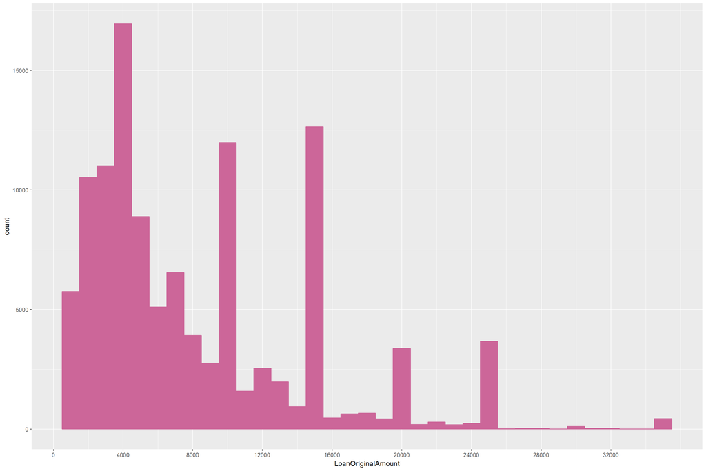

## 2. Term

Lets see how long are these loans usually taken for. It’s expressed in months in the dataset, converting months to year by dividing the term value by 12.

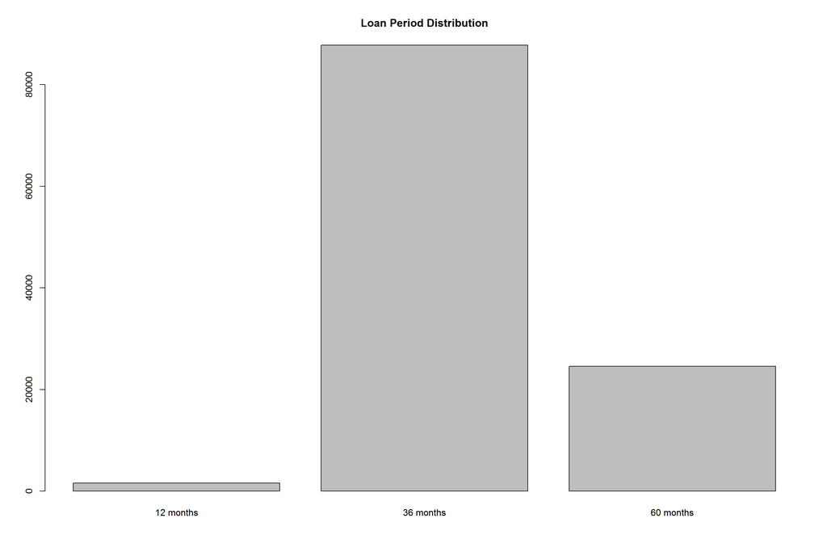

From the above plot, we can clearly say that most of the loans are lent on 36 months (= 3 years) then 60 months (= 5 years) basis. Very few are taken on 12 month basis.

## 3 . Loan Status

Lets see what’s the status of most loans?

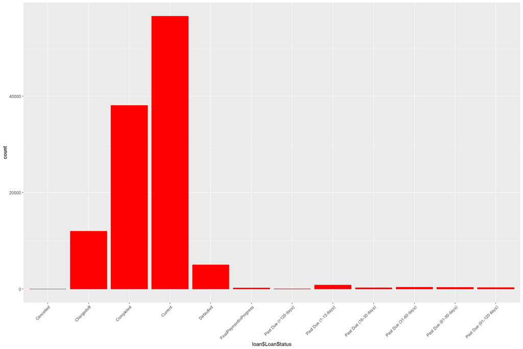

So we see the certain loans have been defaulted and there are a lot of bands which show that they are quite some late payments.

```
## [1] 4.404188
```

```
## [1] 1.81416
```

## 4 . Listing Category

Let’s explore what is the major category under which Prosper loans are issued

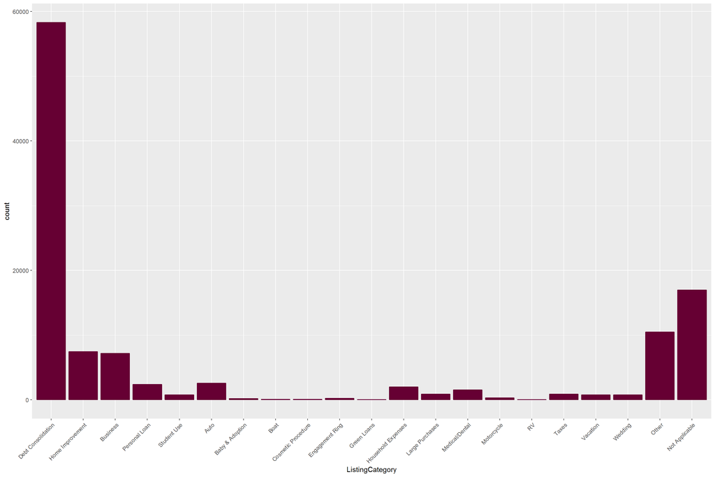

## 5 . Debt to Income Ratio

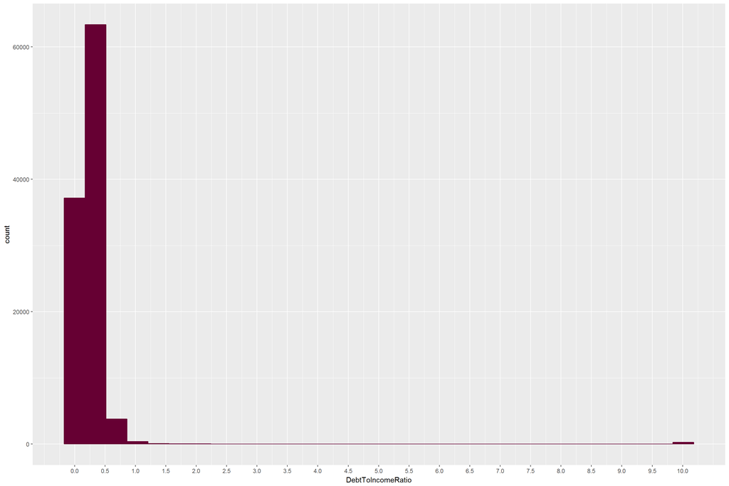

## 6 . Credit Rating

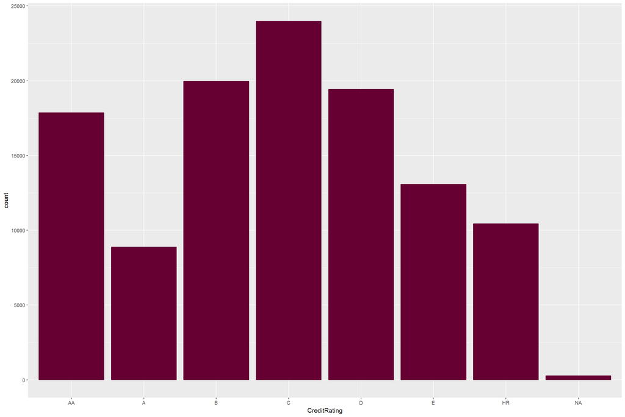

## Borrower’s Characteristics

Let’s explore the data to understand more about our borrowers.

### 1. Borrower’s State

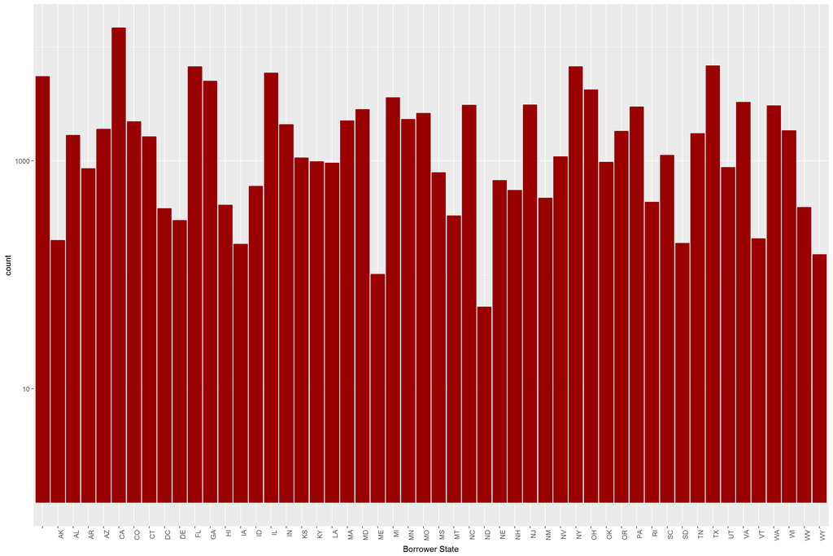

### 2. Rate at which the borrowers are given the loan:

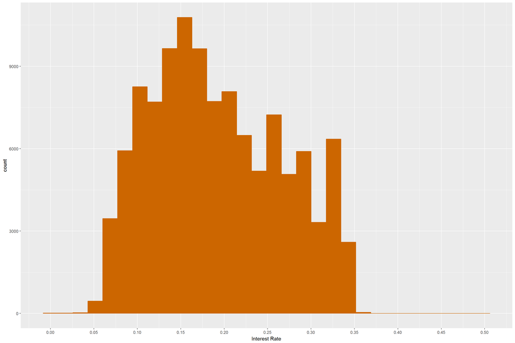

### 3. Income Range of the borrowers:

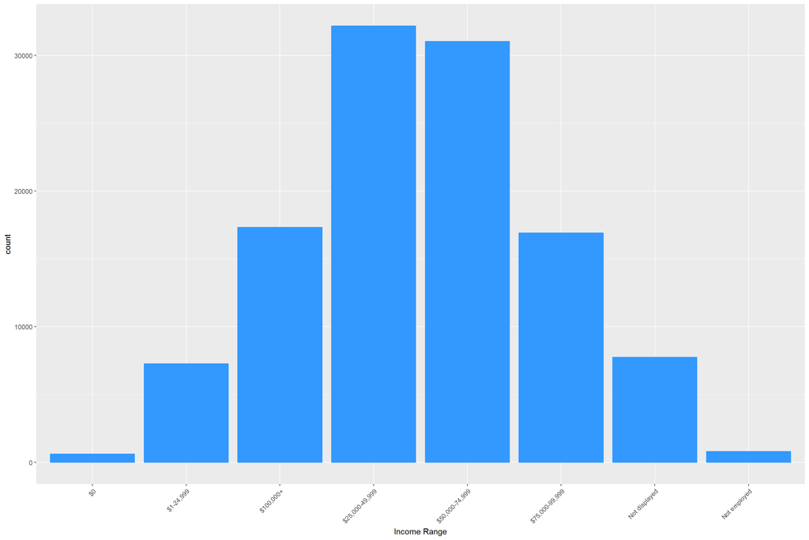

Looks like most of the borrowers belong to low to mid income range. The largest bin has users of income range $25K-50K followed by $50k-75k

### 4. Credit Score:

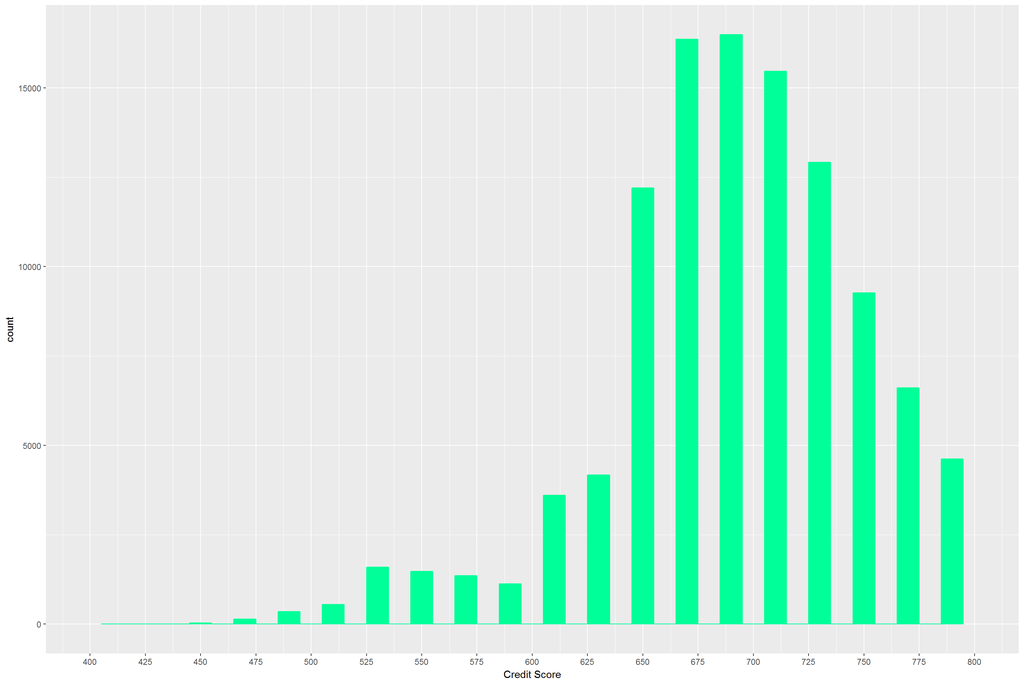

So from the above plot its clear that most of the borrowers have a credit score of 650-750.

## Univariate Analysis

# Bivariate Plots Section

## Correlation Matrix

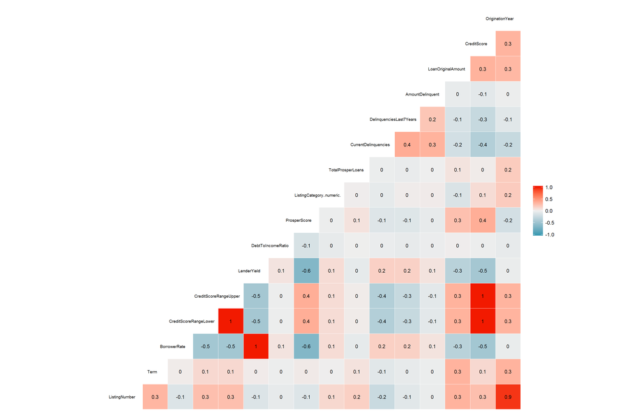

Lets explore and see if there is any relation between the Credit Rating and Credit Score. Just to re-iterate, Credit Rating is a variable which i created by clubbing the columns - Credit Grade and ProperRating..Alpha

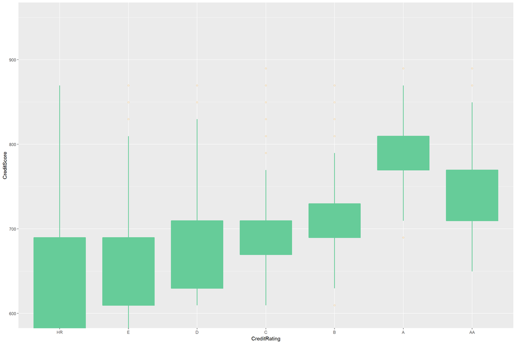

The Credit Rating assigned at the time of the listing was created: 1 - HR, 2 - E, 3 - D, 4 - C, 5 - B, 6 - A, 7 - AA. So, looking at the plot, its clear that as the rating given my prosper is directly propostional to the credit score of the user. But though rating ‘AA’ has higher rating ‘A’ but the median score of AA looks lower than A. Let’s see what summary statistics tell us about this:

```
## loan$CreditRating: AA
##    Min. 1st Qu.  Median    Mean 3rd Qu.    Max.    NA's
##   649.5   709.5   729.5   739.2   769.5   889.5      73
## --------------------------------------------------------
## loan$CreditRating: A
##    Min. 1st Qu.  Median    Mean 3rd Qu.    Max.    NA's
##   689.5   769.5   789.5   787.7   809.5   889.5      92
## --------------------------------------------------------
## loan$CreditRating: B
##    Min. 1st Qu.  Median    Mean 3rd Qu.    Max.    NA's
##   609.5   689.5   709.5   712.4   729.5   869.5      77
## --------------------------------------------------------
## loan$CreditRating: C
##    Min. 1st Qu.  Median    Mean 3rd Qu.    Max.    NA's
##   609.5   669.5   689.5   689.7   709.5   889.5      98
## --------------------------------------------------------
## loan$CreditRating: D
##    Min. 1st Qu.  Median    Mean 3rd Qu.    Max.    NA's
##   609.5   629.5   669.5   671.3   709.5   869.5      78
## --------------------------------------------------------
## loan$CreditRating: E
##    Min. 1st Qu.  Median    Mean 3rd Qu.    Max.    NA's
##   549.5   609.5   649.5   647.3   689.5   869.5      71
## --------------------------------------------------------
## loan$CreditRating: HR
##    Min. 1st Qu.  Median    Mean 3rd Qu.    Max.    NA's
##     9.5   529.5   669.5   632.4   689.5   869.5      91
```

Now exploring Amount borrowed over time by Term

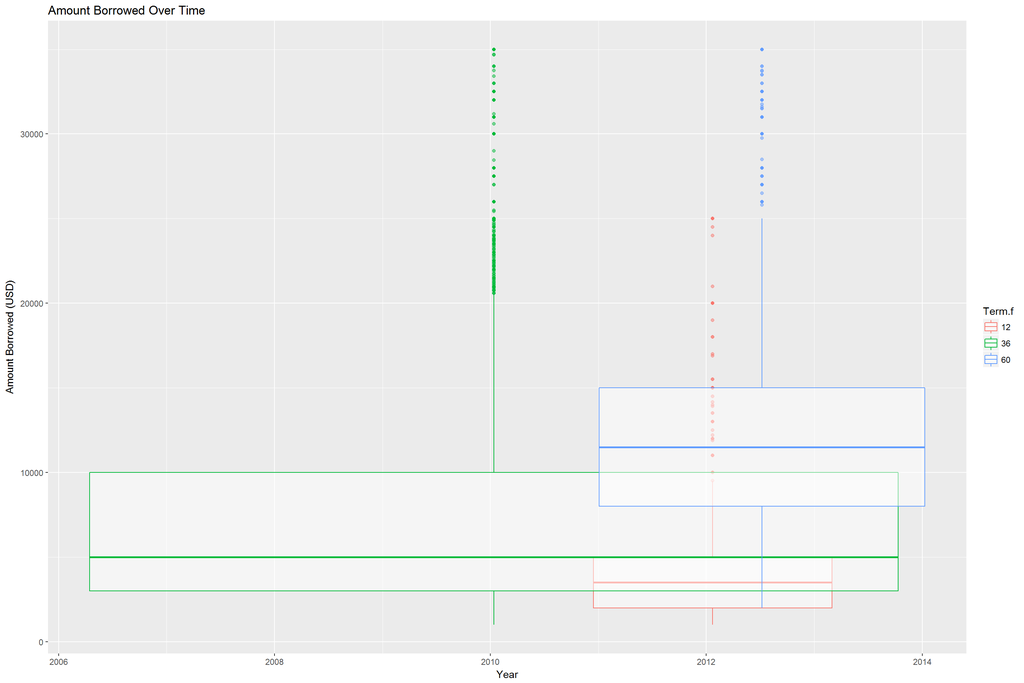

Though the plot isn’t very clear, but it looks like most of the large amount of money has been borrowed for long term usually for 60 months which is a 5 year period.

Lets plot Listing category and the loan Amount

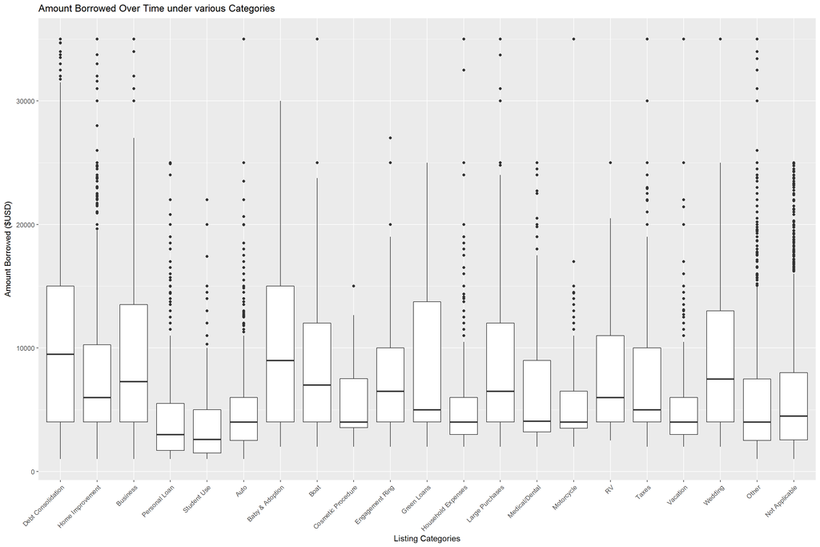

Looks like highest loan amounts are borrowed under ‘Debt Consolidation’ and ‘Baby&Adoption’ category.Lets look at what rate at which these loans are issued

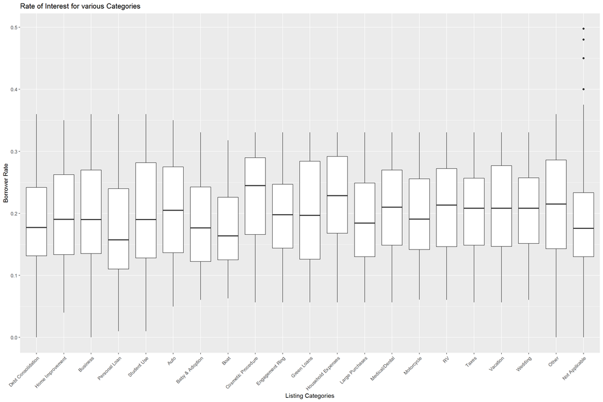

Though the amount borrowed under Debt Consolidation and Baby Adoption is high but the borrower rate is pretty low. The highest rate is for Cosmetic Procedures and Household expenses.

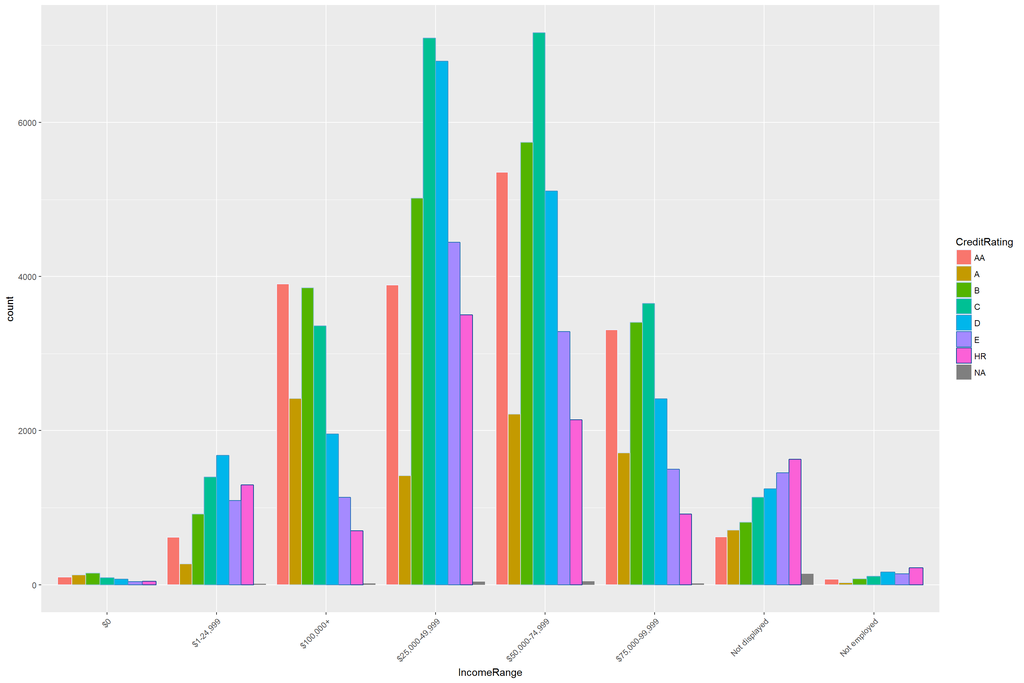

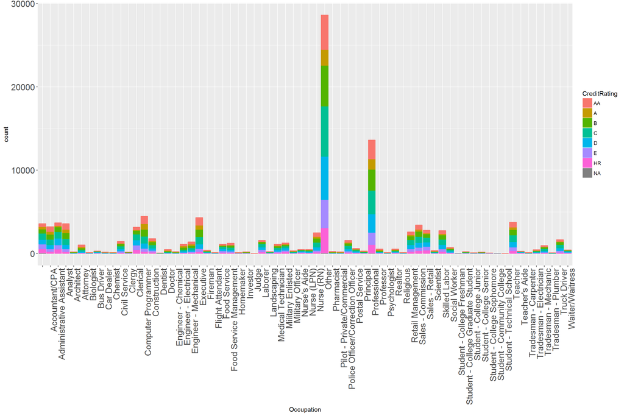

Now, lets see how the loan status varies w.r.t Loan Origination Amount

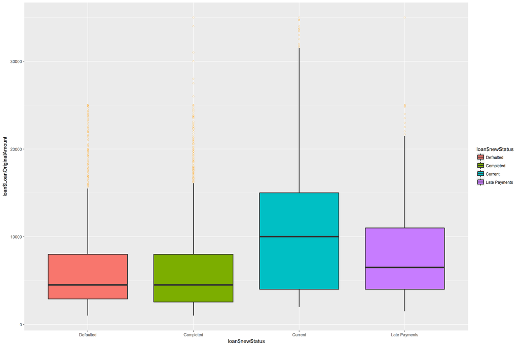

# Bivariate Analysis

The last plot where I explore the loan amount with the loan status. I derived the column column newStatus from the original column Loan Status, where I grouped statuses - Charged Off and Defaulted into Defaulted, Final Payment in Progress into Completed, all the late payments with various day deltas into Late Payments category.I removed the cancelled category and converetd them into NA.

The total dstribution for this new column is as follows

```
##
##     Defaulted     Completed       Current Late Payments
##         17010         38279         56576          2067
```

# Multivariate Plots Section

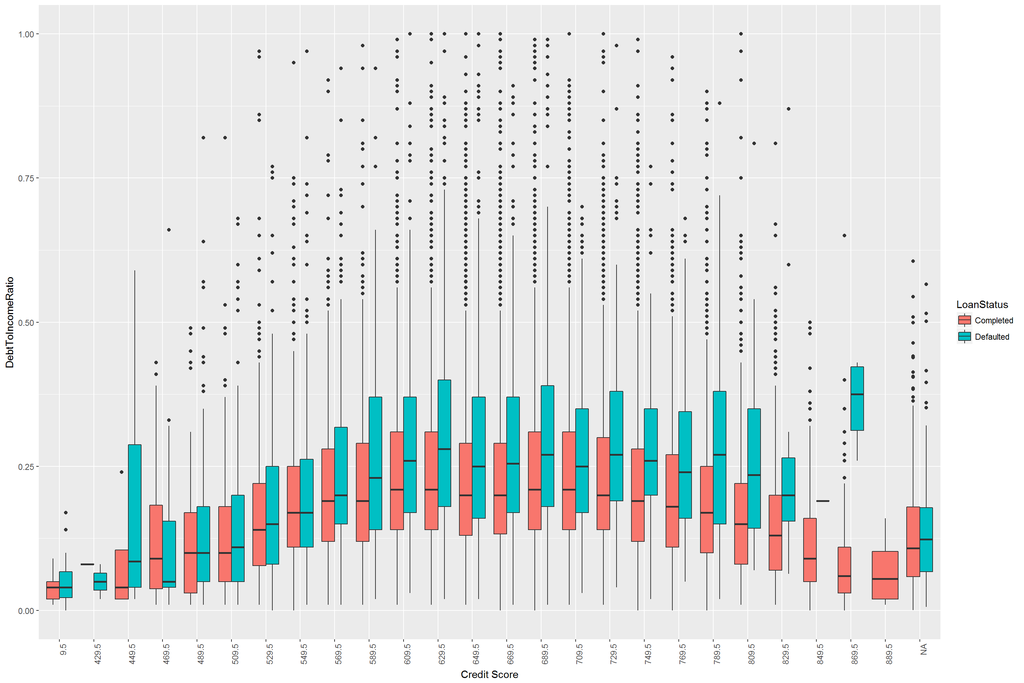

LenderYield w.r.t DebtIncomeRatio

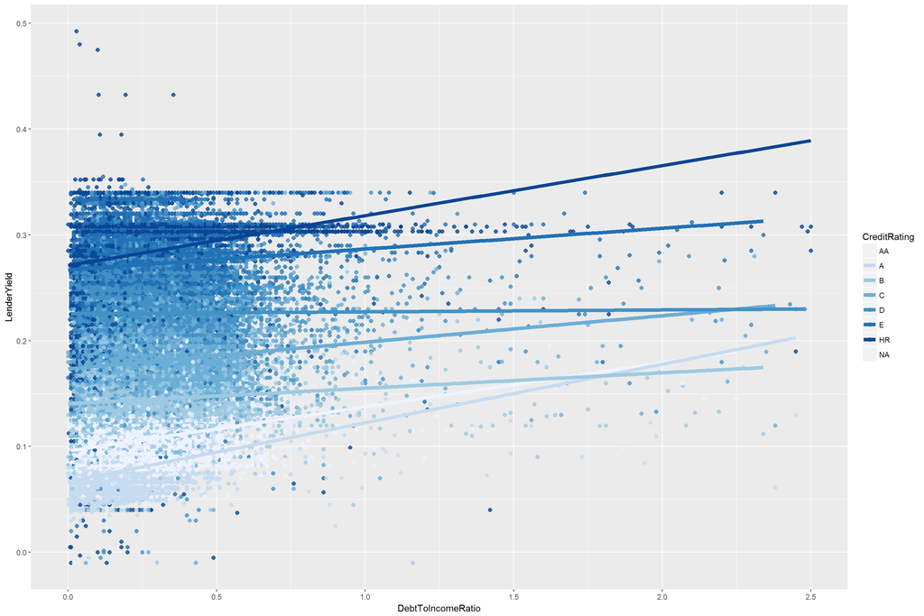

The above two plots of DebttoIncomeRatio vs. Credit Score and LederYield respectively.

# FINAL PLOTS AND ANALYSIS

### Plot One : Time series Plots

Time series plot help us to better visualize the performance of Prosper, we can see the different trend lines, ups and downs of the company.I’m creating a separate dataset from our main dataframe Loan, with the Quarter variable and the original loan amount.

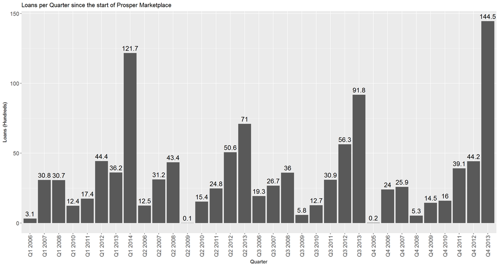

### Plot 2

The second most important plot I found from my exploration is the Distribution of Credit Score.Initial plot had an outlier where the credit score is 9.5. Generally credit score ranges from 400 to 850. Thus, using this i’ll try to scale the x-axis of our credit scores.

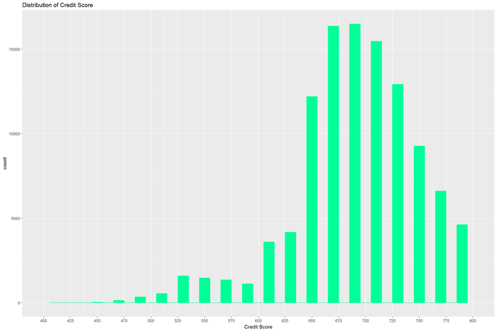

Talking about Borrower Rate and Credit Score. Another intriguing plot, I found was the Debt-to-Income ratio vs. Lender Yield. The lender yield variable is nothing but the rate of interest minus the servicing fees charged by Propser Marketplace.

### Plot 3

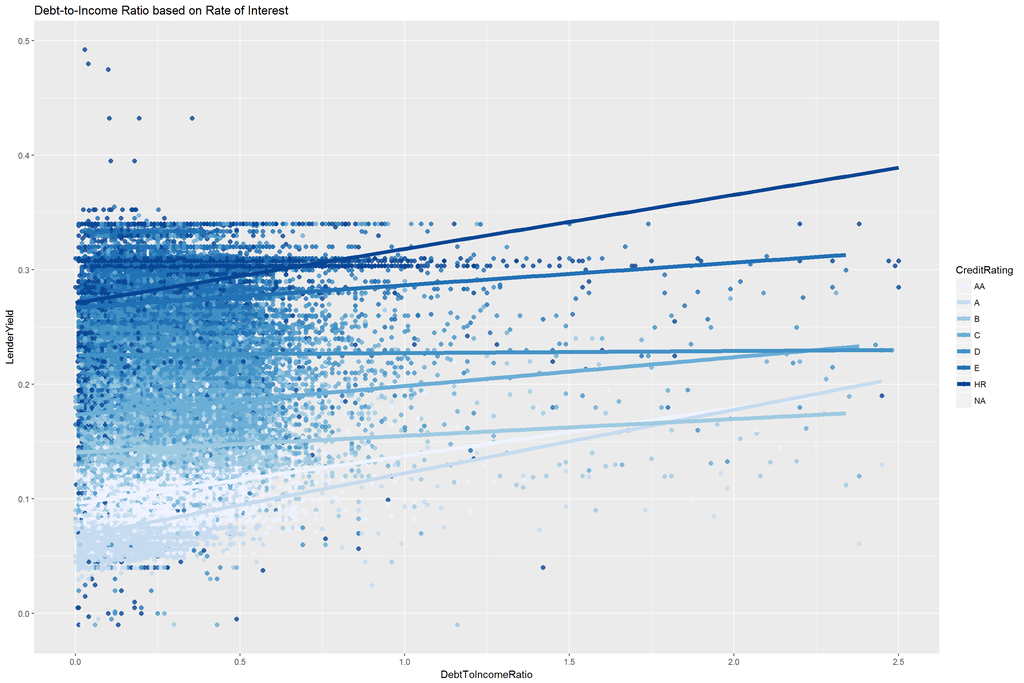

# Reflection

In this analysis, my major hurdle was reading the entire csv due to its huge volume of 114k observations and 81 variables. My first thought to reduce the runtime was to subset the dataset, with my initial understanding of the variables from the Variable Description file, I started off with 15 variables. But as i progressed into my analysis, I realized that these 15 were not enough to get the results I was looking for. This re-iteration of going back to step 1 and re-selecting the variables went on for 3-4 times!Second biggest hurdle, was trying to figure out how to get the ratings for the loans issued before 2009. Since we had a good amount of data from 2007 quarter-1. I finally figured out a way to club the ProperRating..Alpha with the Credit Grade provided, to create a new column called Credit Rating. I also wanted to use the borrower state variable to generate a R-Map to see the  
different counts of defaulters, loanStatus per state. But do to some discrepency with the Mappers library or due to my mistake, I was unable to do so!

There are a number of different ways to take this project further. Firstly, I’ve focused only on a small subset of the variables available in the dataset, and there is a vast amount of data I’vent explored. I think if I better understood the finance/loan terms I would do better justice to this data analysis.I think I’d like to explore the investors side a bit more; look at investor profit and losses. Also, I would like to learn about the kind of plots and graphs specifically used by the finance industry, so that I can incorporate that knowledge into any future datasets I may explore, like using density line graphs showing spikes by time period.